# Mr report

Anas M.

Collaborator

7/29/2021

Abstract

This is our paragraph

It has two paras.

# Header 1

Bigger

## Header 2

Big

### Header 3

Pretty Big

#### Header 4

Bold face header

# Intro to Rmd formatting

Here example of **bold** text, **bod** Here is an example of *italic*, *italic* Here is an example of *bold italic*, *bold italic* what about superscripts x<sup>2</sup>, subscript x<sub>0</sub> underline underline = *no*!

Here example of **bold** text, **bod** Here is an example of *italic*, *italic* Here is an example of *bold italic*, *bold italic* what about superscripts x<sup>2</sup>, subscript x<sub>0</sub> underline underline = *no*!

Line 1  
Line 2

Line 1  
Line 2

* `<br>` starts a new line, not a paragraph

topic 1> Topic para

Topic 2. blah blah

Topic 3. blah..blah…blah

Here is a sentence with a footnote[^1]. This sentence follows footnote[^2].

This is the introduction of our document and we want to include importnat information from a person in the field.

> This a quote from importnat person.

> This is second quote from a *really* important person.

> > This is a nested quote from 2nd person.

Here is our lists for roadmap

1. item 1
2. item 2
3. item 3

Numbers doesn’t matter

1. item 1
2. item 2
3. item 3

Symbol list

- item 1
- item 2
- item 3

A different symbol

- item 1
- item 2
- item 3

Sublists

1. item 1
   1. subitem 1
2. item 2
   1. subitem 1
   2. subitem 2
3. item 3

We can include blockquotes within out lists

> This is a super important list
> 1. item 1
> 2. item 2
> 3. item 3

If we want to provide further description of items

1. item 1

   This is a paragraph is a descreption of item 1. This is a paragraph is a descreption of item 1. This is a paragraph is a descreption of item 1.
2. item

   This is a descreption of item 2.This is a descreption of item 2.This is a descreption of item 2.
3. item 3

   > this is our blockquote for item 3.this is our blockquote for item 3.this is our blockquote for item 3.this is our blockquote for item 3.this is our blockquote for item 3.this is our blockquote for item 3.

Demo of a messy table

| Col1 | Col2 | Col3 | Col4 |
| --- | --- | --- | --- |
| 100 | 20 | 10 | 13 |
| 140 | 30 | 9 | 1 |
| 12 | 6 | 0 | 54 |

Demo of a clean table

[output not shown]

Let’s include few links that are *important*. One way https://rmarkdown.rstudio.com/lesson-1.html or with hyperlink name of link

#Intro to code chunks

this is R figure

```r
x<-rnorm(n=100, mean = 5, sd = 1)
y<-2+2*x+rnorm(n=100)
```

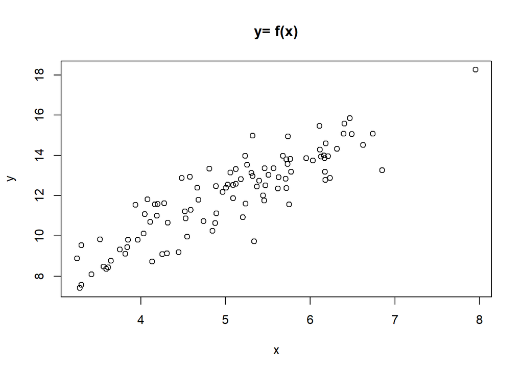

```r
plot(x, y, main="y= f(x)")
```

Our response variable $y$ is distributed $\mathcal{N}(\mu, \sigma^2)$, where
$$\begin{align}
\mu &= 2 + 2E[x] + E[e] \\
\sigma^2 &= 2^2Var[x] + 1^2Var[e] + 2*2*1Cov(x, e)
\end{align}$$

$$y = f(x)$$

Our small sample provides $\mu=$ 12.0696753 and $\sigma^2=$ 4.3952138.

Our small sample provides $\mu=$ 12.07 and $\sigma^2=$ 4.4.

Demo of a messy table

[output not shown]

Table: Demo of a `R` table

# Bigger and better data

```r
df_all <- read_csv('data/daily_bike_data.csv')
df_temp <- df_all%>%
  select(cnt, temp)
```

```r
ss_df_temp <- sapply(df_temp,
                     function(j)
                     c(mean(j), min(j), max(j), sd(j)))%>%
  data.frame()%>%
  round(digits=2)

row.names(ss_df_temp) <- c('mean', 'min', 'max', 'sd')

ss_df_temp%>%kableExtra::kable(caption ='Summary statistics')
```

Summary statistics

|  | cnt | temp |
| --- | --- | --- |
| mean | 4504.35 | 0.50 |
| min | 22.00 | 0.06 |
| max | 8714.00 | 0.86 |
| sd | 1937.21 | 0.18 |

Here is a graphical relationship between `cnt` and `remp`

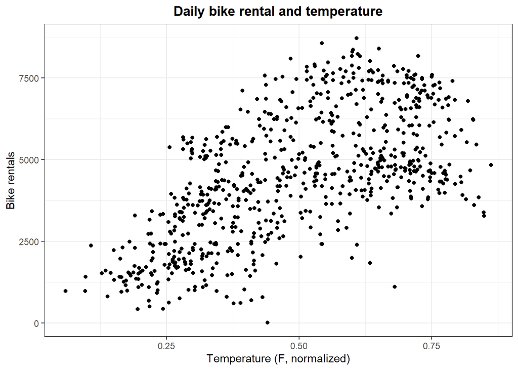

```r
ggplot(data=df_temp, aes(temp, cnt))+
  theme_bw()+
  geom_point()+
  labs(title= 'Daily bike rental and temperature', x = 'Temperature (F, normalized)',
  y= 'Bike rentals')+
  theme(plot.title = element_text(face='bold', hjust=0.5))
```

```r
df_temp <- df_temp%>%
  mutate(temp2 = temp^2)

#Contruct linear model for slope
mod1 <- lm(cnt~temp, data=df_temp)

#Contruct basic expansion for curvature question
mod2 <- lm(cnt~., data=df_temp)

#get model predictions
pred_mod1<-predict(mod1, df_temp['temp'])
pred_mod2<-predict(mod2, df_temp[c('temp', 'temp2')])

#Update df
pred_dftemp<-df_temp%>%
  mutate(cnt_mod1=pred_mod1,
         cnt_mod2=pred_mod2)
```

Presented below are model summary statistics

```r
summary(mod1)$coefficient%>%
  kableExtra::kable(caption = 'Model 1 summary (Dep. cnt)', digits =3)
```

Model 1 summary (Dep. cnt)

|  | Estimate | Std. Error | t value | Pr(>\|t\|) |
| --- | --- | --- | --- | --- |
| (Intercept) | 1214.642 | 161.164 | 7.537 | 0 |
| temp | 6640.710 | 305.188 | 21.759 | 0 |

```r
broom::tidy(mod2)%>%
  kable(caption = 'Model 2 summary (Dep. cnt)', digits =3)
```

Model 2 summary (Dep. cnt)

| term | estimate | std.error | statistic | p.value |
| --- | --- | --- | --- | --- |
| (Intercept) | -1901.956 | 382.391 | -4.974 | 0 |
| temp | 21406.931 | 1685.202 | 12.703 | 0 |
| temp2 | -15055.025 | 1692.522 | -8.895 | 0 |

Here is what models looks like with data

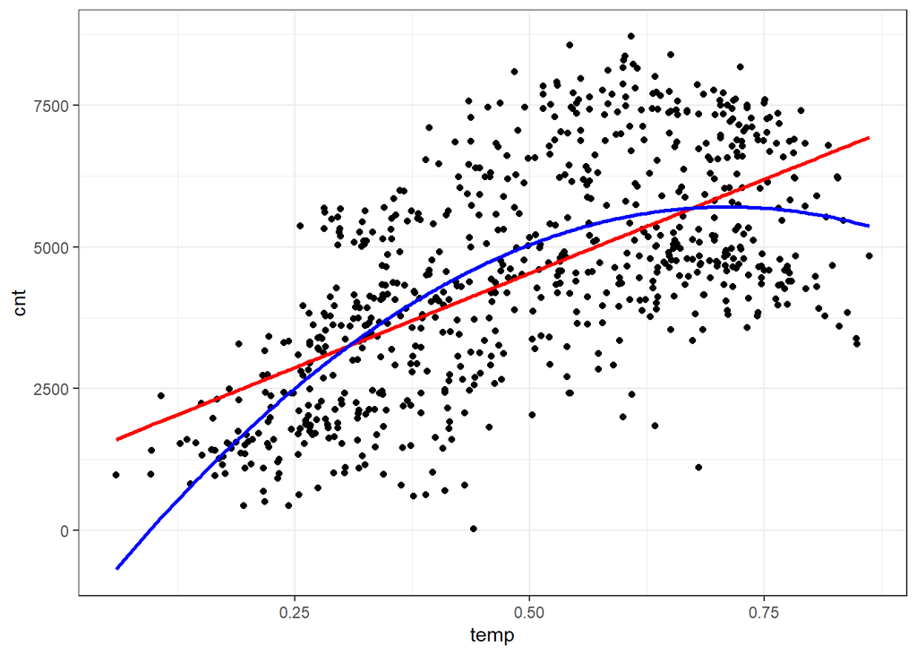

```r
ggplot(data=pred_dftemp, aes(temp, cnt))+
  theme_bw()+
  geom_point()+
  geom_line(aes(temp, cnt_mod1), color='red', size=1)+
  geom_line(aes(temp, cnt_mod2), color='blue', size=1)+
  theme(plot.title = element_text(face='bold', hjust=0.5))
```

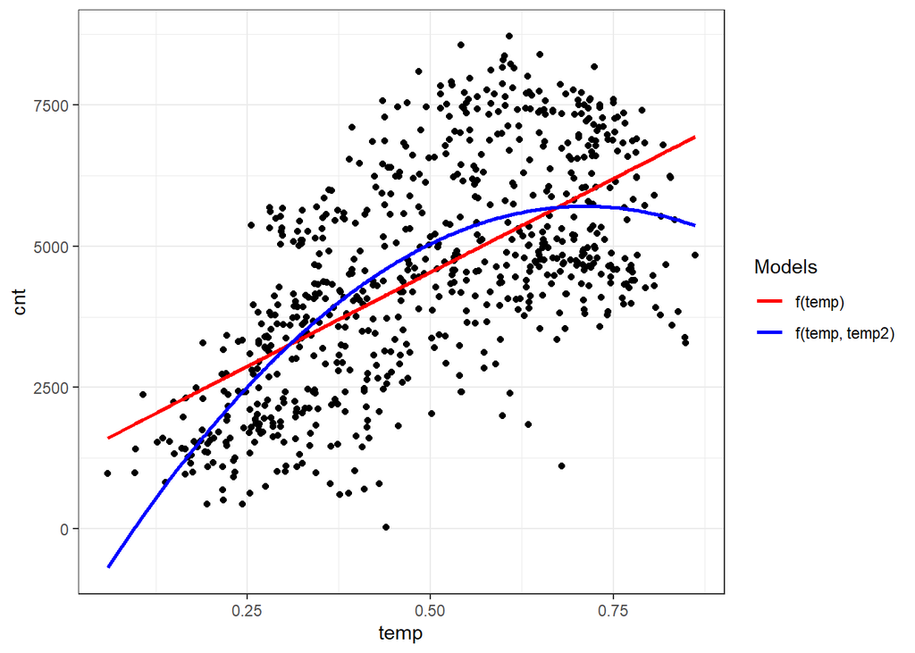

```r
ggplot(data=pred_dftemp, aes(temp, cnt))+
  theme_bw()+
  geom_point()+
  geom_line(aes(temp, cnt_mod1, color='f(temp)'),  size=1)+
  geom_line(aes(temp, cnt_mod2, color='f(temp, temp2)'),  size=1)+
  theme(plot.title = element_text(face='bold', hjust=0.5))+
  scale_color_manual(name = 'Models',
                     values=c('f(temp)' = 'red',
                              'f(temp, temp2)' = 'blue'))
```

[^1]: Here is the 1st footnote.
[^2]: second footnote.